# R Notebook

### UČITAVANJE PAKETA

Učitavam potrebne pakete i korisim sve 32 jezgre za zahtjevne operacije.

```r
library(data.table)
library(xts)
library(quantmod)
library(fmlr)
library(tseries)
library(data.table)
library(reticulate)
library(here)
library(future.apply)
source(here("R", "import_data.R"))
source(here("R", "features.R"))
source(here("R", "outliers.R"))
source(here("R", "parallel_functions.R"))
source(here("R", "execution.R"))
# performance
plan(multiprocess)  # for multithreading  workers = availableCores() - 8)
```

### PARAMETRI

```r
# import data
contract = 'SPY5'
upsample = FALSE
# file name prefix
file_name <- paste0(contract, '-', upsample, '-')
```

### UČITAVANJE PODATAKA

Svaku strategiju sam testirao sa razli;itom frekventnosti podatraka. Najčešće sam koristio minutne, 5-minutne, sate i dnevne podatke. Poneka 10-minutne ili polusatne frekvencije.

```r
# HFD
market_data <- import_mysql(
  contract = contract,
  save_path = 'D:/market_data/usa/ohlcv',
  trading_days = TRUE,
  upsample = upsample,
  RMySQL::MySQL(),
  dbname = 'odvjet12_market_data_usa',
  username = 'odvjet12_mislav',
  password = 'Theanswer0207',
  host = '91.234.46.219'
)
vix <- import_mysql(
  contract = 'VIX5',
  save_path = 'D:/market_data/usa/ohlcv',
  trading_days = TRUE,
  upsample = upsample,
  RMySQL::MySQL(),
  dbname = 'odvjet12_market_data_usa',
  username = 'odvjet12_mislav',
  password = 'Theanswer0207',
  host = '91.234.46.219'
)
```

### PREPROCESSING

Predprocesne radnje za sve strategije su vrlo jednostavne. Eliminiram ourliere, prpojim VIX podatke, dodam input varijable (npr, povrate, volatilnost, kurtoyis i drugo), dodam pomaknute vrijednosti i eliminiram redove s NA vrijendosti.

```r
# Remove outliers
market_data <- remove_outlier_median(market_data, median_scaler = 25)

# merge market data and VIX
market_data <- merge(market_data, vix[, 'close'], join = 'left')
colnames(market_data)[ncol(market_data)] <- 'vix'
market_data <- na.omit(market_data)

# Add features
market_data <- add_features(market_data)

# lags
market_data$returns_lag <- data.table::shift(market_data$returns)
market_data$vix_lag <- data.table::shift(market_data$vix)

# Remove NA values
market_data <- na.omit(market_data)
```

Ideja za ovaj korak u budućnosti je korištenje wavelet transformacija.

### BACKCusum strategija

IDeja je koristiti statističke testove strukturnih lomova kako bi se identificirao lom u seriji. Zatim se poyizicije zauzimaju u trenutku pojave loma. Na primjer, ako test pokaže da je probijena gornja granica za seriju volatilnosti možemo izaći iz pozicije. Ili ako se pokaže da je kvadrat prinosa probiju gornju granicu, izlazimo iz pozicije. Ideja je da se strukturni lom na povrat ne može dugoročno održati.

```r
quantile(market_data$bc_standardized_returns_greater, seq(0, 1, 0.05), na.rm = TRUE)
```

```
       0%        5%       10%       15%       20%       25%       30%       35%       40%       45%       50%       55%       60%       65%       70%       75%
0.0007880 0.4136670 0.4637150 0.5021715 0.5347550 0.5649617 0.5932205 0.6200975 0.6459710 0.6717293 0.6979125 0.7252280 0.7536660 0.7844255 0.8175290 0.8542620
      80%       85%       90%       95%      100%
0.8980770 0.9505018 1.0185725 1.1267447 2.5161530
```

Za procjenu strukturnog loma sam koristio metodu iz novog rada (2020), BackCUSUM test. Koraci strategije us dakle jednostavni:

1. Za odrešenu duljinu prozora (npr. 100, dakle za prethodnih sto minuta), napravi se statistički BackCUSUM test.
2. Utvrdimo vrijeme u kojem je statistika prešla određenu kritičnu vrijednost, pri čemu granicu određujemo sami.
3. Smjer za sljedći *bar* ovisi o koriptenoj varijabli. Na primjer, ako koristimo (standardizirane) povrate, lom na gornu granicu podrazumijeva izlazak iz pozicije.

```r
quantile(backcusum_mean, seq(0, 1, 0.05), na.rm = TRUE)
```

```
       0%        5%       10%       15%       20%       25%       30%       35%       40%       45%       50%       55%       60%       65%       70%       75%
0.4449233 0.5871309 0.6138744 0.6317031 0.6467340 0.6600247 0.6724389 0.6842511 0.6960834 0.7074496 0.7183975 0.7300954 0.7415796 0.7537622 0.7666267 0.7809345
      80%       85%       90%       95%      100%
0.7980095 0.8168893 0.8420986 0.8827003 1.1691551
```

Provjeravao sam osjetljivost strategije na različite parametre, ali neij se pokazala uspješnom.

### DYNAMIC PROGRAMING SEGMENTS (DPSEG) STRATEGIJA

Ideja strtegije je praćenje trenda. `dpseg` paket u R-u omogućuje segmentiranje serije na jednake ‘ravne’ dijelove. Kratak opis paketa je [ovdje](https://cran.r-project.org/web/packages/dpseg/vignettes/dpseg.html). Strategija se opet sastoji od 3 koraka:

1. Za odrešenu duljinu prozora (npr. 100, dakle za prethodnih sto minuta), napravi se linearna segmentacija serije.
2. Sprema se zadnja vrijendost koeficijenta za svaki prozor.
3. Smjer za sljedći *bar* ovisi o vrijdnosti koeficijenta. ako je koeficijent jako pozitivan izlazimo iz pozicije jer očekujemo promjenu trenda.

```r
dpseg_roll <- function(data, window_size = 100) {
  DT <- as.data.table(market_data)[, .(time = index, price = close)][, time := as.numeric(time)]
  dpseg_last <- slider_parallel(
    .x = DT,
    .f =   ~ {
      library(dpseg)
      segs <- dpseg(.x$time, .x$price, jumps=FALSE, store.matrix=TRUE, verb=FALSE, P = 0.1)
      slope_last <- segs$segments$slope[length(segs$segments$slope)]
      slope_last
    },
    .before = window_size - 1,
    .after = 0L,
    .complete = TRUE,
    n_cores = -1
  )
  dpseg_last <- unlist(dpseg_last)
  dpseg_last <- c(rep(NA, window_size - 1), dpseg_last)
  return(dpseg_last)
}
results_dpseg <- dpseg_roll(market_data, 400)
```

```
[1] "Number of subsamples (max used cores): 727"
[1] "The fucntion took -2.34781361818314"
```

```r
quantile(results_dpseg, seq(0, 1, .05), na.rm = TRUE)
```

```
           0%            5%           10%           15%           20%           25%           30%           35%           40%           45%           50%
-8.350000e-03 -3.266131e-05 -1.449559e-05 -8.274317e-06 -5.365235e-06 -3.313910e-06 -2.054455e-06 -1.005735e-06 -2.100951e-07  5.209029e-07  1.190215e-06
          55%           60%           65%           70%           75%           80%           85%           90%           95%          100%
 1.879120e-06  2.576595e-06  3.368113e-06  4.364113e-06  5.741857e-06  7.902906e-06  1.154031e-05  1.785290e-05  3.806062e-05  1.505000e-02
```

[output not shown]

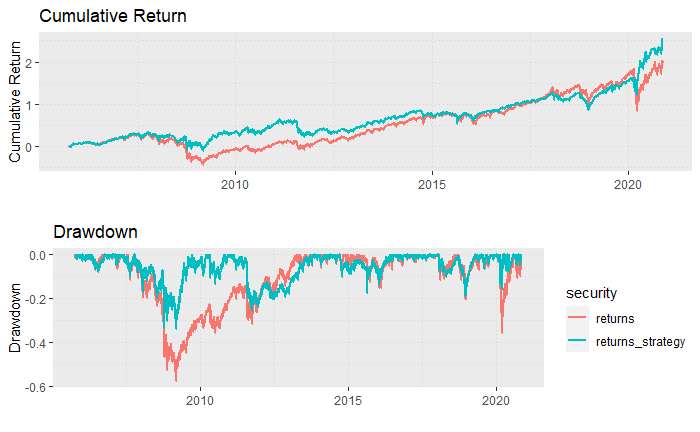

```r
results_2 <- cbind(market_data, slope = results_dpseg)
results_2$sign <- ifelse(results_2$slope > 0.000005, 0L, 1)
results_2$sign <- shift(results_2$sign, 1L, type = 'lag')
results_2$returns_strategy <- results_2$returns * results_2$sign
PerformanceAnalytics::charts.PerformanceSummary(results_2[, c('returns', "returns_strategy")], plot.engine = 'ggplot2')
```

### STRATEGIJA VARIJACIJE KOEFICIJENATA

Keficijenti nisu statični kroz vrijeme nego se mijenjaju. Na primjer, korelacija prethodnog i sadašnjeg bara može biti 0.7 u prosjeku, ali u pojedinim periodima može biti 0.3 ili 1.1. Ideja strategije je pratiti vrijendost koeficijenta na određenoj duljini prozora i utvrditi smjer trgoanja kada koeficijent naraste ili padne iznad neke kritične vrijednosti.

[figure not shown]

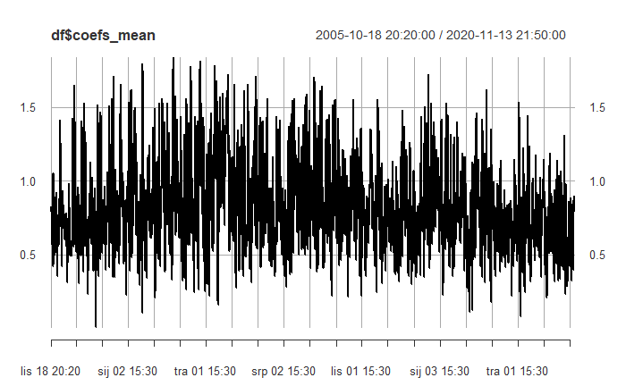

### DRUGE STRATEGIJE

Dodatne strategije: - Exuber u R-u - Jednostavni momentum - kupi ako je raslo u prethodnih n raydoblja. - Jednostavna VIX strategija - kupi ako je VIX iznad određene vrijednosti.

### IDEJE

Razvoj strategija za manje institucionalne ulagače ili sofisticirane investitore.

Razvoj stetagija koje se temelj na faktor investiranju

Uključiti opcije. Na primjer kupiti put opciju ako vrijednost VIX-a naraste.

Koristiti tekstualne podatkeČ preplata na određeni datafeed.